# Lab3Qs

```python
import os

import matplotlib.pyplot as plt
from matplotlib.colors import ListedColormap, BoundaryNorm
import numpy as np
import xarray as xr
import rioxarray as rxr
import earthpy as et
import earthpy.plot as ep

# Prettier plotting with seaborn
import seaborn as sns
sns.set(font_scale=1.5, style="whitegrid")

from matplotlib import cm
from matplotlib.colors import ListedColormap,LinearSegmentedColormap
```

```python
lidar_chm = rxr.open_rasterio('earth-analytics/data/colorado-flood/spatial/outputs/pre-flood-chm.tif')
```

```python
print("The crs is", lidar_chm.rio.crs)
print("The no data value is", lidar_chm.rio.nodata)
```

```
The crs is EPSG:32613
The no data value is None
```

```python
print("The spatial resolution is", lidar_chm.rio.resolution())
```

```
The spatial resolution is (1.0, -1.0)
```

This describes the resolution of the .tif file I opened. It's in raster format.

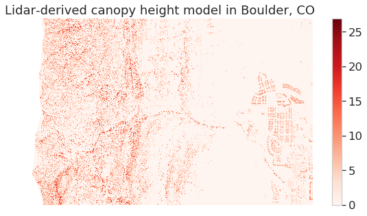

```python
f, ax = plt.subplots(figsize=(10, 5))
lidar_chm.plot(cmap="Reds")
ax.set_title("Lidar-derived canopy height model in Boulder, CO")
ax.set_axis_off()
plt.show()
```

## Creates a classified raster map that shows positive and negative change in the canopy height model before and after the flood.

```python
os.chdir(os.path.join(et.io.HOME,
                      'earth-analytics',
                      'data'))
```

```python
pre_dtm_path = os.path.join("colorado-flood",
                        "spatial",
                        "boulder-leehill-rd",
                        "pre-flood",
                        "lidar",
                        "pre_DTM.tif")

pre_dsm_path = os.path.join("colorado-flood",
                        "spatial",
                        "boulder-leehill-rd",
                        "pre-flood",
                        "lidar",
                        "pre_DSM.tif")
# Open DTM and DSM files
pre_lidar_dtm = rxr.open_rasterio(pre_dtm_path, masked=True).squeeze()
pre_lidar_dsm = rxr.open_rasterio(pre_dsm_path, masked=True).squeeze()

# Create canopy height model (CHM)
pre_lidar_chm = pre_lidar_dsm - pre_lidar_dtm
pre_lidar_chm
```

```
<xarray.DataArray (y: 2000, x: 4000)>
array([[       nan,        nan,        nan, ..., 0.        , 0.17004395,
        0.960083  ],
       [       nan,        nan,        nan, ..., 0.        , 0.09008789,
        1.6400146 ],
       [       nan,        nan,        nan, ..., 0.        , 0.        ,
        0.07995605],
       ...,
       [       nan,        nan,        nan, ..., 0.        , 0.        ,
        0.        ],
       [       nan,        nan,        nan, ..., 0.        , 0.        ,
        0.        ],
       [       nan,        nan,        nan, ..., 0.        , 0.        ,
        0.        ]], dtype=float32)
Coordinates:
    band         int64 1
  * x            (x) float64 4.72e+05 4.72e+05 4.72e+05 ... 4.76e+05 4.76e+05
  * y            (y) float64 4.436e+06 4.436e+06 ... 4.434e+06 4.434e+06
    spatial_ref  int64 0
```

This section of code defines the path for both the Digital Surface Model (DSM) and Digital Terrain Model (DTM) so that python knows where to find the files. Both files are raster format, derived from lidar, and are from pre-flood conditions. Next, I opened both files using rasterio. I then got rid of no data values by using 'masked=True', and reduced the third dimension by using .squeeze(). This ensures data values are reasonable and helps with processing. Finally, I determined the Canopy Height Model (CHM) by subtracting the DTM for the DSM. This gave me the finall CHM in pre-flood conditions.

```python
post_dtm_path = os.path.join("colorado-flood",
                        "spatial",
                        "boulder-leehill-rd",
                        "post-flood",
                        "lidar",
                        "post_DTM.tif")

post_dsm_path = os.path.join("colorado-flood",
                        "spatial",
                        "boulder-leehill-rd",
                        "post-flood",
                        "lidar",
                        "post_DSM.tif")
# Open DTM and DSM files
post_lidar_dtm = rxr.open_rasterio(post_dtm_path, masked=True).squeeze()
post_lidar_dsm = rxr.open_rasterio(post_dsm_path, masked=True).squeeze()

# Create canopy height model (CHM)
post_lidar_chm = post_lidar_dsm - post_lidar_dtm
post_lidar_chm
```

```
<xarray.DataArray (y: 2000, x: 4000)>
array([[0.02001953, 0.        , 0.        , ..., 0.        , 0.        ,
        0.98010254],
       [0.        , 0.        , 0.        , ..., 0.        , 0.        ,
        1.4000244 ],
       [0.        , 0.        , 0.        , ..., 0.        , 0.        ,
        0.        ],
       ...,
       [0.        , 0.        , 0.        , ..., 0.        , 0.        ,
        0.        ],
       [0.        , 0.        , 0.        , ..., 0.        , 0.        ,
        0.        ],
       [0.04003906, 0.        , 0.        , ..., 0.        , 0.        ,
        0.        ]], dtype=float32)
Coordinates:
    band         int64 1
  * x            (x) float64 4.72e+05 4.72e+05 4.72e+05 ... 4.76e+05 4.76e+05
  * y            (y) float64 4.436e+06 4.436e+06 ... 4.434e+06 4.434e+06
    spatial_ref  int64 0
```

This section follows the same exact logic and format as the previous block, except it results in the CHM in post flood conditions.

```python
# Are the bounds the same?
print("Is the spatial extent the same?",
      pre_lidar_chm.rio.bounds() == post_lidar_chm.rio.bounds())

# Is the resolution the same ??
print("Is the resolution the same?",
      pre_lidar_chm.rio.resolution() == post_lidar_chm.rio.resolution())

diff_lidar_chm = post_lidar_chm - pre_lidar_chm
```

```
Is the spatial extent the same? True
Is the resolution the same? True
```

This block checks that both the pre and post CHM have the same spatial extent and resolution. They do. I checked this to ensure that the following operation would be accurate. I then subtracted the pre flood CHM from the post flood CHM. This results in the CHM difference after the flood. I subtracted the pre flood from the post flood, and not the other way around, because this would result in the gains being postive numbers, and the losses negetive numbers.

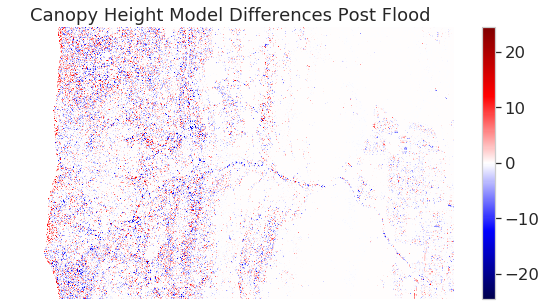

```python
f, ax = plt.subplots(figsize=(10, 5))
diff_lidar_chm.plot(cmap="seismic")
ax.set(title="Canopy Height Model Differences Post Flood")
ax.set_axis_off()
plt.show()
```

This block of code plots the change in canopy height using a diverging scale. I chose this scale because red shows gains and blue shows losses. I chose to plot this in order to get an idea of what the map should look like.

```python
print('CHM min value:', np.nanmin(diff_lidar_chm))
print('CHM max value:', np.nanmax(diff_lidar_chm))
```

```
CHM min value: -23.429932
CHM max value: 24.45996
```

This block prints the minimum and maximum of the CHM values, exluding the non data values. I check these values to get an idea of what the data range looks like.

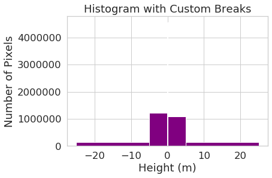

```python
# Histogram with custom breaks
f, ax = plt.subplots()
diff_lidar_chm.plot.hist(color="purple",
                        bins=[-25, -5, -0.1, 0.1, 5, 25])
ax.set(title="Histogram with Custom Breaks",
       xlabel="Height (m)",
       ylabel="Number of Pixels")

plt.show()
```

Here, I created a histogram to visualize the data distribution. It looks like while there are some really high and low values, most are clustered close to zero. This information helps me pick bin sizes to best visualize the data.

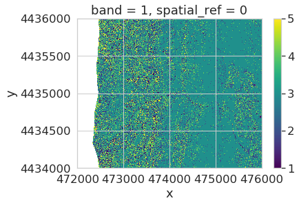

```python
class_bins = [-np.inf, -5, -0.1, 0.1, 5, np.inf]
diff_lidar_chm_class = xr.apply_ufunc(np.digitize,
                                     diff_lidar_chm,
                                     class_bins)
diff_lidar_chm_class_ma = diff_lidar_chm_class.where(diff_lidar_chm_class != 6)
im = diff_lidar_chm_class_ma.plot.imshow()
ax.set_axis_off()
```

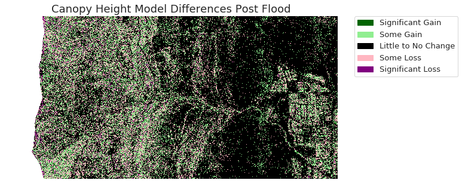

```python
# Create a list of labels to use for your legend
height_class_labels = ["Significant Gain",
                       "Some Gain",
                       "Little to No Change",
                       "Some Loss",
                       "Significant Loss"]

# Create a colormap from a list of colors
colors = ['darkgreen',
          'lightgreen',
          'black',
          'lightpink',
          'purple']

cmap = ListedColormap(colors)

class_bins = [1.0, 2.0, 3.0, 4.0, 5.0, 6.0]
norm = BoundaryNorm(class_bins,
                    len(colors))

# Plot newly classified and masked raster
f, ax = plt.subplots(figsize=(10, 5))
im = diff_lidar_chm_class_ma.plot.imshow(cmap=cmap,
                                        norm=norm,
                                        # Turn off colorbar
                                        add_colorbar=False)
# Add legend using earthpy
ep.draw_legend(im,
               titles=height_class_labels)
ax.set(title="Canopy Height Model Differences Post Flood")
ax.set_axis_off()
plt.show()
```

## Creates a classified raster map that shows positive and negative change in terrain extracted from the pre and post flood Digital Terrain Models before and after the flood.

```python
diff_lidar_dtm = post_lidar_dtm - pre_lidar_dtm
print('DTM min value:', np.nanmin(diff_lidar_dtm))
print('DTM max value:', np.nanmax(diff_lidar_dtm))
```

```
DTM min value: -19.609985
DTM max value: 47.100098
```

This block determines the difference in the Digital Terrain Models (DTM) after flood conditions. I also print the minimum and maximum DTM values, exluding no data values, to get an idea of what the data looks like.

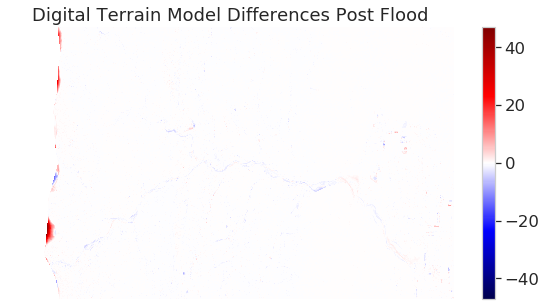

```python
f, ax = plt.subplots(figsize=(10, 5))
diff_lidar_dtm.plot(cmap="seismic")
ax.set(title="Digital Terrain Model Differences Post Flood")
ax.set_axis_off()
plt.show()
```

This block of code plots the change in digital terrain using a diverging scale. I chose this scale because red shows gains and blue shows losses. I chose to plot this in order to get an idea of what the map should look like. It looks like there are a few very high or very low data points that take over the visual, while most values are smaller and not really represented in this. Because of this, I will have to be careful when picking bin sizes.

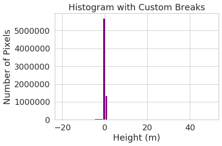

```python
# Histogram with custom breaks
f, ax = plt.subplots()
diff_lidar_dtm.plot.hist(color="purple",
                        bins=[-20, -5, -1, 0.1, 1, 5, 50])
ax.set(title="Histogram with Custom Breaks",
       xlabel="Height (m)",
       ylabel="Number of Pixels")

plt.show()
```

Here, I created a histogram to visualize the data distribution. It looks like while there are some really high and low values, most are clustered close to zero. This information helps me pick bin sizes to best visualize the data.

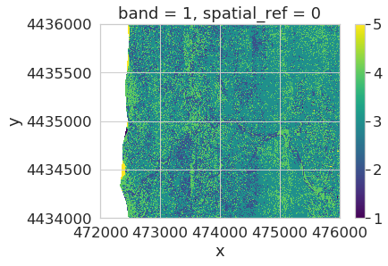

```python
class_bins = [-np.inf, -5, -0.1, 0.1, 5, np.inf]
diff_lidar_dtm_class = xr.apply_ufunc(np.digitize,
                                     diff_lidar_dtm,
                                     class_bins)
diff_lidar_dtm_class_ma = diff_lidar_dtm_class.where(diff_lidar_dtm_class != 6)
im = diff_lidar_dtm_class_ma.plot.imshow()
ax.set_axis_off()
```

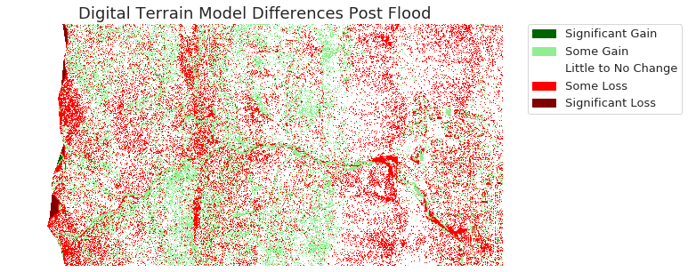

```python
# Create a list of labels to use for your legend
height_class_labels = ["Significant Gain",
                       "Some Gain",
                       "Little to No Change",
                       "Some Loss",
                       "Significant Loss"]

# Create a colormap from a list of colors
colors = ['darkgreen',
          'lightgreen',
          'white',
          'red',
          'maroon']

cmap = ListedColormap(colors)

class_bins = [1.0, 2.0, 3.0, 4.0, 5.0, 6.0]
norm = BoundaryNorm(class_bins,
                    len(colors))

# Plot newly classified and masked raster
f, ax = plt.subplots(figsize=(10, 5))
im = diff_lidar_dtm_class_ma.plot.imshow(cmap=cmap,
                                        norm=norm,
                                        # Turn off colorbar
                                        add_colorbar=False)
# Add legend using earthpy
ep.draw_legend(im,
               titles=height_class_labels)
ax.set(title="Digital Terrain Model Differences Post Flood")
ax.set_axis_off()
plt.show()
```